# 2018 Griffith Gridiron Red Zone Report

## Week 14

*Alex Wagner, 12/04/2018*

Hello all and welcome to our traditional Griffith Gridiron fantasy football seasonal reports. The first report this year comes with only a week left in the regular season, but there are still hopefuls to root for (or against) and close matchups that will affect their postseason aspirations! The final week of the regular season is upon us, and through week 13 there remain a few postseason slots in contention. This report uses our previous performance and current standings to predict each team's chances of making the championship, winning the playoffs, or getting last place. This is accomplished through simulating millions of matchups based on the remaining season schedule.

## Environment Setup and Function Declarations

*Click the button below to see the methods used to generate this report*

```python
from IPython.display import HTML

HTML('''<script>
code_show=true;
function code_toggle() {
 if (code_show){
 $('div.input').hide();
 } else {
 $('div.input').show();
 }
 code_show = !code_show
}
$( document ).ready(code_toggle);
</script>
<form action="javascript:code_toggle()"><input type="submit" value="Click here to toggle on/off the raw code."></form>''')
```

```python
%matplotlib inline
import numpy as np
import scipy.stats
import matplotlib as plt
import seaborn as sns
import time
from collections import Counter
from bs4 import BeautifulSoup
import requests
import multiprocessing
LEAGUE_ID=402051
YEAR=2018
```

```python
# Load records from public ESPN league
url = 'http://games.espn.com/ffl/standings?leagueId={0}&seasonId={1}'.format(LEAGUE_ID, YEAR)
r = requests.get(url)
r.raise_for_status()
soup = BeautifulSoup(r.content, "lxml")
```

```python
table = soup.find('table', {'id': 'xstandTbl_div0'})
rows = table.findAll('tr', {'class': 'sortableRow'})
records = dict()
COMPLETED_WEEKS = 0
for row in rows:
    pf = row.find('td', {'class': 'sortablePF'}).text
    record = row.find('td', {'class': 'sortableDIV'}).text
    teamName = row.find('td').a.text
    win, loss, tie = record.split('-')
    COMPLETED_WEEKS = int(win) + int(loss) + int(tie)
    records[teamName] = (int(win), int(loss), float(pf))
```

```python
# Load schedule from public ESPN league
url = 'http://games.espn.com/ffl/schedule?leagueId={0}'.format(LEAGUE_ID)
r = requests.get(url)
r.raise_for_status()
soup = BeautifulSoup(r.content, "lxml")
```

```python
rows = soup.find('table', {'class': "tableBody"}).findAll('tr', {'class': 'tableSubHead'})
schedule = dict()
for week, row in enumerate(rows, 1):
    matchups = list()
    matchup = row.findNextSibling()
    while(matchup.attrs['bgcolor'] != '#ffffff'):
        links = matchup.findAll('a')
        team1 = links[0].text
        team2 = links[1].text
        matchups.append((team1, team2))
        matchup = matchup.findNextSibling()
    schedule[week] = matchups
```

```python
# Optionally add in manual win-loss for current week
def add_winner(winners, records, schedule):
    current_week = schedule[COMPLETED_WEEKS + 1]
    if set(winners) < set(records.keys()):
        raise ValueError('Expected winners to be a proper subset of teams')
    for winner in winners:
        matchup_idx = [winner in x for x in current_week].index(True)
        # More to do here
```

```python
def simulate_matchup(week, records, team1, team2):
    r1 = records[team1]
    r2 = records[team2]
    team1_mean = r1[2]/(week - 1)
    team2_mean = r2[2]/(week - 1)
    team1_score = round(np.random.normal(team1_mean, team1_mean / 10),2)
    team2_score = round(np.random.normal(team2_mean, team2_mean / 10),2)
    if team1_score > team2_score:
        a = 1
        b = 0
        winner = team1
        loser = team2
    elif team2_score > team1_score:
        a = 0
        b = 1
        winner = team2
        loser = team1
    else:
        return simulate_matchup(week, records, team1, team2)
    team1_result = (r1[0] + a, r1[1] + b, r1[2] + team1_score)
    team2_result = (r2[0] + b, r2[1] + a, r2[2] + team2_score)
    return { 'winner': winner,
             'loser': loser,
             'values': (team1_result, team2_result) }
```

```python
def simulate_season_rank():
    new_records = records.copy()
    for week in range(COMPLETED_WEEKS + 1,15):
        for matchup in schedule[week]:
            r = simulate_matchup(week, new_records, *matchup)
            new_records[matchup[0]], new_records[matchup[1]] = r['values']
    r = new_records
    return sorted(r, key=lambda x: (r[x][0], r[x][2]), reverse=True)
```

```python
def simulate_ROS():
    r = simulate_season_rank()
#     for i, team in enumerate(r, start=1):
#         outcomes[team].append(i)
    round_1 = (simulate_matchup(14, records, r[0], r[3])['winner'],
               simulate_matchup(14, records, r[1], r[2])['winner'])
    round_2 = simulate_matchup(14, records, *round_1)['winner']
    champion = round_2
    round_1 = (simulate_matchup(14, records, r[-4], r[-1])['loser'],
       simulate_matchup(14, records, r[-3], r[-2])['loser'])
    round_2 = simulate_matchup(14, records, *round_1)['loser']
    last = round_2
    return champion, last, r
```

```python
def simulate_n(chunk_size):
    outcomes = {team: [] for team in records.keys()}
    playoff_wins = Counter()
    last_place_finish = Counter()

    for _ in range(chunk_size):
        r = simulate_ROS()
        playoff_wins[r[0]] += 1
        last_place_finish[r[1]] += 1
        for i, team in enumerate(r[2], start=1):
            outcomes[team].append(i)
    return playoff_wins, last_place_finish, outcomes
```

## Simulating Remaining Matchups

```python
%%time
trials = 1000000
chunk_size = 10000
outcomes = {team: [] for team in records.keys()}
playoff_wins = Counter()
last_place_finish = Counter()

with multiprocessing.Pool(7) as p:
    results = p.map(simulate_n, [chunk_size] * (trials // chunk_size))

for r in results:
    playoff_wins += r[0]
    last_place_finish += r[1]
    for team, o in r[2].items():
        outcomes[team] += o

for team in outcomes:
    outcomes[team] = np.array(outcomes[team])
```

```
CPU times: user 1.53 s, sys: 205 ms, total: 1.74 s
Wall time: 45.4 s
```

```python
# %%time
# trials = 1000000
# outcomes = {team: [] for team in records.keys()}
# playoff_wins = Counter()
# last_place_finish = Counter()

# for _ in range(trials):
#     r = simulate_season_rank()
#     for i, team in enumerate(r, start=1):
#         outcomes[team].append(i)
#     round_1 = (simulate_matchup(13, records, r[0], r[3])['winner'],
#                simulate_matchup(13, records, r[1], r[2])['winner'])
#     round_2 = simulate_matchup(13, records, *round_1)['winner']
#     playoff_wins[round_2] += 1
#     round_1 = (simulate_matchup(13, records, r[-4], r[-1])['loser'],
#        simulate_matchup(13, records, r[-3], r[-2])['loser'])
#     round_2 = simulate_matchup(13, records, *round_1)['loser']
#     last_place_finish[round_2] += 1

# for team in outcomes:
#     outcomes[team] = np.array(outcomes[team])
```

## Results

### Distribution of Possible Outcomes

*Ranks left of the green line indicate outcomes where a team makes the playoffs. Ranks right of the red line indicate outcomes where a team will participate in the last-place playoffs.*

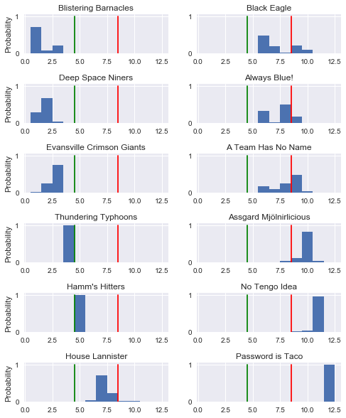

```python
teams = len(outcomes)
rows = teams // 2
f, axarr = plt.pyplot.subplots(rows, 2)
for i, team in enumerate(sorted(outcomes,
                                key=lambda x: scipy.stats.describe(outcomes[x]).mean)):
    row = i % rows
    column = i // rows
    axarr[row, column].hist(outcomes[team], bins=np.array(range(teams+1))+0.5, normed=True)
    if row == rows:
        axarr[row, column].set_xlabel('Rank')
    if column == 0:
        axarr[row, column].set_ylabel('Probability')
    axarr[row, column].set_title(team)
    x = 4.5
    axarr[row, column].plot([4.5, 4.5], [0, 1], 'g')
    x = teams - 3.5
    axarr[row, column].plot([x, x], [0, 1], 'r')
plt.pyplot.subplots_adjust(top = 1.5, hspace = 0.8)
```

### Overall Probability of Making the Playoffs

```python
overall_playoffs = dict()
for team in outcomes:
    percent = sum(outcomes[team] <= 4) / trials
    overall_playoffs[team] = percent
for team in sorted(outcomes,
                   key=lambda x: (overall_playoffs[x],
                                  scipy.stats.describe(outcomes[x]).mean * -1),
                   reverse=True):
    print('{0:<21} {1:7.2%}'.format(team + ':', overall_playoffs[team]))
```

```
Blistering Barnacles: 100.00%
Deep Space Niners:    100.00%
Evansville Crimson Giants: 100.00%
Thundering Typhoons:  100.00%
Hamm's Hitters:         0.00%
House Lannister:        0.00%
Black Eagle:            0.00%
Always Blue!:           0.00%
A Team Has No Name:     0.00%
Assgard Mjölnirlicious:   0.00%
No Tengo Idea:          0.00%
Password is Taco:       0.00%
```

### Overall Probability of Winning the Championship

```python
for team in sorted(playoff_wins, key=lambda x: playoff_wins[x], reverse=True):
    percent = playoff_wins[team] / trials
    print('{0:<21} {1:7.2%}'.format(team + ':', percent))
```

```
Blistering Barnacles:  51.17%
Deep Space Niners:     28.13%
Thundering Typhoons:   15.37%
Evansville Crimson Giants:   5.34%
```

### Overall Probability of Last Place Contest

```python
overall_last_contest = dict()
for team in outcomes:
    percent = sum(outcomes[team] > teams - 4) / trials
    overall_last_contest[team] = percent
for team in sorted(outcomes,
                   key=lambda x: (overall_last_contest[x],
                                  scipy.stats.describe(outcomes[x]).mean * -1),
                   reverse=True):
    print('{0:<21} {1:7.2%}'.format(team + ':', overall_last_contest[team]))
```

```
Password is Taco:     100.00%
No Tengo Idea:         99.97%
Assgard Mjölnirlicious:  97.45%
A Team Has No Name:    51.32%
Black Eagle:           31.79%
Always Blue!:          16.25%
House Lannister:        3.21%
Blistering Barnacles:   0.00%
Deep Space Niners:      0.00%
Evansville Crimson Giants:   0.00%
Thundering Typhoons:    0.00%
Hamm's Hitters:         0.00%
```

### Overall Probability of Getting Last Place Trophy

```python
for team in sorted(last_place_finish, key=lambda x: last_place_finish[x], reverse=True):
    percent = last_place_finish[team] / trials
    print('{0:<21} {1:7.2%}'.format(team + ':', percent))
```

```
Password is Taco:      80.58%
No Tengo Idea:         11.85%
Assgard Mjölnirlicious:   5.10%
A Team Has No Name:     1.87%
Always Blue!:           0.37%
Black Eagle:            0.21%
House Lannister:        0.02%
```

# Discussion

## The Final Countdown

### A Sure Bet

Congratulations to the **Blistering Barnacles**, **Deep Space Niners**, and **Evansville Crimson Giants**. These teams are a solid lock for the playoffs, and can rest easy in week 14. The 2018 **Barnacles** are especially inspiring, as Obi has turned around a 5-9 2015 season and postseason *Toilet Bowl* trophy into a true Cinderella story, currently projected as most likely to win the championship (51.17% of outcomes) on breakout seasons for both Aaron Jones and The Chicago Bears D/ST. Conversely, despite a strong early- and mid-season, Malachi and the **Thundering Typhoons** have lost their last 2 games, and now face likely back-to-back losses from their Captain-Haddock-themed counterpart.

### So You're Telling Me There's a Chance

The **Hitters** technically have a chance to leverage the **Typhoons** plight into a playoff slot, but after losing to the lackluster **Lannister**s in week 13 the odds are long (< 0.01% of outcomes). Accomplishing this would require an extremely unlikely point differential (+148.7 points) against the **Typhoons** to eclipse their total points-for in the final game of the regular season. Of course, this *did* happen at least once this season already (**Barnacles** outscored **Taco** by 167.4 points in Week 10), but we're largely talking about miracles at this scale.

## Race to the Bottom

On the other end of our league, the contest to not finish last is also largely decided. Things are looking particularly grim for **Password is Taco**, **No Tengo Idea**, and **Assgard Mjölnirlicious**, each of whom are essentially locked into the bottom 4, with less than a 3% margin of escape.

### Stay Vigilant

Notably, last year's champion **Black Eagle** has fallen far from their rookie performance, ending in the bottom 4 in 31.79% of outcomes after going 1-5 in the second half of the season. Susanna is in a must-win situation and needs to right the ship quickly if she hopes to avoid the depths, as her primary competition **House Lannister** has gone .500 over that same stretch and is strongly favored to win against **Password is Taco** in week 14.

### Time for a Change

Speaking of, the terrible **Taco**s are in dismal disrepair after Peter avoided the waiver wire almost every week (7 total acquisitions) and set a new record for the most inactive players started in league history (13 inactive players over 9 weeks, 13 total roster moves). If there's ever been a clear-cut favorite for the golden toilet seat, it's this team. The dubious distinction may yet be avoidable with some savvy picks and an eye on winning in weeks 15 and 16--pay close attention to the waivers in the coming weeks!